# Logistic regression modeling

Nina Li

May 14, 2019

Source: [Quantiatie Geography](https://rspatial.org/raster/analysis/6-local_regression.html)

```r
# load packages
library(raster)
library(rgdal)
library(dismo)
library(mgcv)
library(fields)
library(glmnet)
```

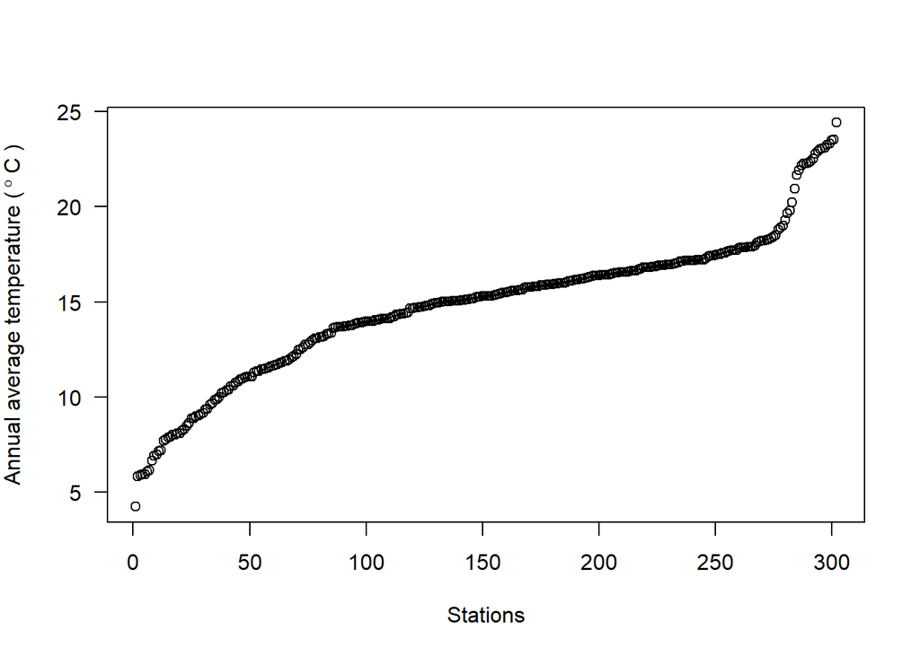

```r
# load California boundary
datapath <- ("D:/Ninalty/Ninalty_CV/ENG_Datascience/Week7/")
CA <- shapefile(file.path(datapath, "counties_2000.shp"))

d <- read.csv(file.path(datapath, "temperature.csv"))
d$temp <- rowMeans(d[, c(6:17)])
plot(sort(d$temp), ylab=expression('Annual average temperature ( '~degree~'C )'),
las=1, xlab='Stations')
```

Make a simple map of temperature

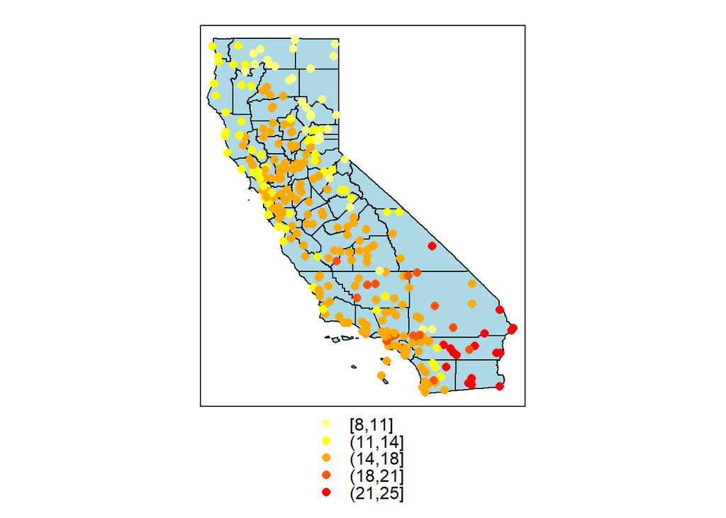

```r
dsp <- SpatialPoints(d[,3:4], proj4string=CRS("+proj=longlat +datum=NAD83"))

dsp <- SpatialPointsDataFrame(dsp, d)
cuts <- c(8,11,14,18,21,25)
pols <- list("sp.polygons", CA, fill = "lightblue")
print(spplot(dsp, 'temp', cuts=cuts, sp.layout=pols,
col.regions=rev(heat.colors(5))))
```

Transformation

```r
# assign coordinates information
TA <- CRS(" +proj=aea +lat_1=34 +lat_2=40.5 +lat_0=0 +lon_0=-120 +x_0=0
+y_0=-4000000 +datum=NAD83 +units=m +no_defs +ellps=GRS80 +towgs84=0,0,0")

# convert the coordinate system
dta <- spTransform(dsp, TA)
cata <- spTransform(CA, TA)
```

Sampling for cross-validation

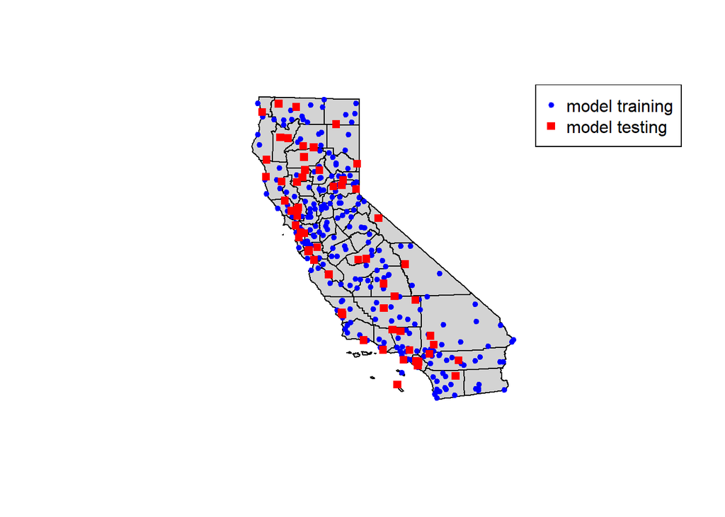

```r
# set test and train datasets
set.seed(5162016)
k <- kfold(dta)

# take a look at the dataset
test <- dta[k==1, ]
train <- dta[k!=1, ]

plot(cata, col='light gray')
points(train, pch=20, col='blue')
points(test, pch=15, col='red')
legend('topright', c('model training', 'model testing'), pch=c(20, 15), col=c('blue', 'red'))
```

Fit the linear model

```r
# format the data
df <- data.frame(coordinates(train), temp=train$temp)
colnames(df)[1:2] = c('x', 'y')

head(df)
```

```
##          x         y     temp
## 1 536702.1 -398253.1 23.30000
## 2 448682.2 -419894.1 23.00833
## 3 421253.6 -458238.7 23.07500
## 4 407653.6 -333021.6 17.07500
## 5 404865.9 -273898.6 14.10833
## 6 415879.2 -573215.8 22.25833
```

Fit a linear model to the data  
The summary shows that x has no significant relationship with temperature. x is logitude here.  
Temperature has negative relationship with y, which is the latitude here.

```r
m <- glm(temp ~ x+y, data=df)
summary(m)
```

```
##
## Call:
## glm(formula = temp ~ x + y, data = df)
##
## Deviance Residuals:
##     Min       1Q   Median       3Q      Max
## -9.5810  -1.5613   0.1474   1.8181   8.8619
##
## Coefficients:
##               Estimate Std. Error t value Pr(>|t|)
## (Intercept)  1.390e+01  2.135e-01  65.073  < 2e-16 ***
## x            7.109e-07  1.521e-06   0.467    0.641
## y           -8.675e-06  1.100e-06  -7.887  1.1e-13 ***
## ---
## Signif. codes:  0 '***' 0.001 '**' 0.01 '*' 0.05 '.' 0.1 ' ' 1
##
## (Dispersion parameter for gaussian family taken to be 8.236277)
##
##     Null deviance: 3579.8  on 241  degrees of freedom
## Residual deviance: 1968.5  on 239  degrees of freedom
## AIC: 1202
##
## Number of Fisher Scoring iterations: 2
```

Question 3: According to this model. How much does the temperature in California change if you travel 500 miles to the north (show the R code to compute that)

```r
#create a new dataframe for the comparison
df2 <- df

#add 500miles to the y value
df2$y <- df2$y+1609.34 #convert the miles to meter

#predict the temperature with y+500 miles
p2 <- predict(m, df2)

#get the difference in temperature
dif <- p2-df2$temp
df2$dif <- dif

mean(df2$dif)
```

```
## [1] -0.01396122
```

```r
v <- data.frame(coordinates(test))
colnames(v)[1:2] = c('x', 'y')
p <- predict(m, v)
head(p)
```

```
##        1        2        3        4        5        6
## 18.67154 17.67720 17.39930 17.94395 16.28229 18.12864
```

```r
# now the linear model
RMSE <- function(observed, predicted) {
sqrt(mean((predicted - observed)^2, na.rm=TRUE))
}
RMSE(p, test$temp)
```

```
## [1] 2.84847
```

Predictions

```r
# prepare data
r <- raster(round(extent(cata)), res=10000, crs=TA)
# get the x coordinates
x <- init(r, v='x')
# set areas outside of CA to NA
x <- mask(x, cata)
# get the y coordinates
y <- init(r, v='y')
# combine the two variables (RasterLayers)
s <- stack(x,y)
names(s) <- c('x', 'y')
```

Now make a model with all data

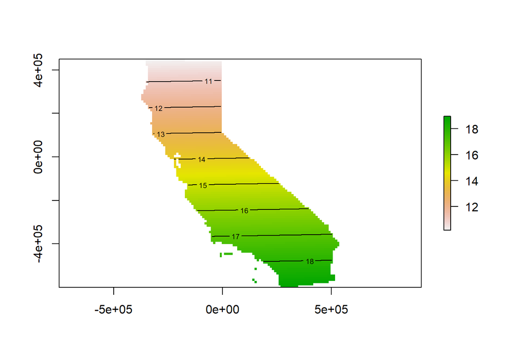

```r
df <- data.frame(coordinates(dta), temp=dta$temp)
colnames(df)[1:2] = c('x', 'y')

m <- glm(temp ~ ., data=df)

# predict
trend <- predict(s, m)
plot(trend)
contour(trend, add=TRUE)
```

Try second order polynomials and interactions betwen x and y.

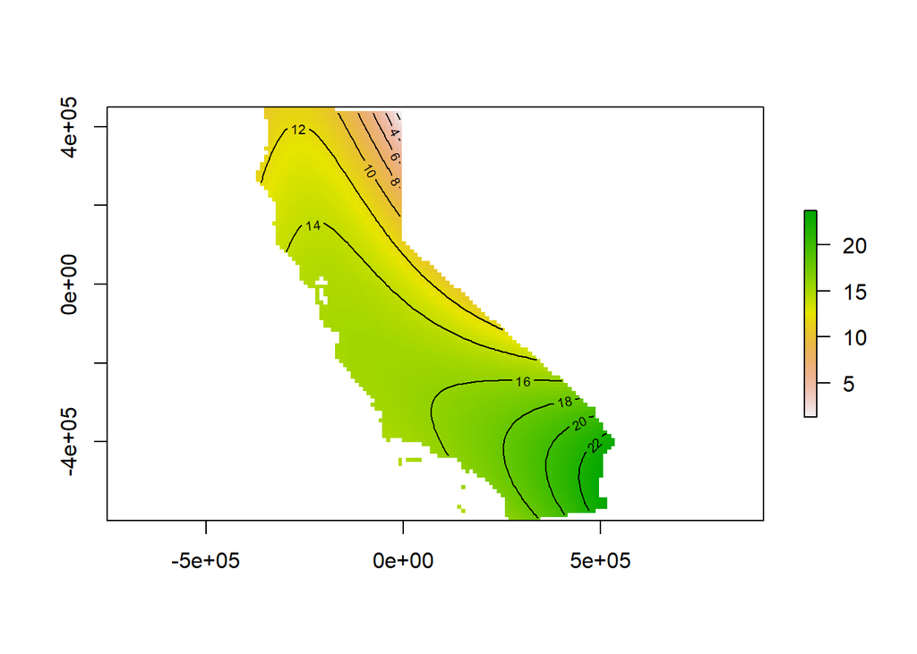

```r
m <- glm(temp ~ poly(x, 2, raw=TRUE) * poly(y, 2, raw=TRUE), data=df)
summary(m)
##
## Call:
## glm(formula = temp ~ poly(x, 2, raw = TRUE) * poly(y, 2, raw = TRUE),
##     data = df)
##
## Deviance Residuals:
##      Min        1Q    Median        3Q       Max
## -10.4185   -0.9676    0.1926    1.4591   10.8233
##
## Coefficients:
##                                                   Estimate Std. Error t value
## (Intercept)                                      1.338e+01  3.014e-01  44.398
## poly(x, 2, raw = TRUE)1                         -1.595e-05  2.719e-06  -5.867
## poly(x, 2, raw = TRUE)2                         -4.384e-11  1.162e-11  -3.773
## poly(y, 2, raw = TRUE)1                         -1.636e-05  1.353e-06 -12.097
## poly(y, 2, raw = TRUE)2                         -2.987e-11  4.383e-12  -6.816
## poly(x, 2, raw = TRUE)1:poly(y, 2, raw = TRUE)1 -1.032e-10  1.596e-11  -6.468
## poly(x, 2, raw = TRUE)2:poly(y, 2, raw = TRUE)1 -1.899e-16  3.735e-17  -5.084
## poly(x, 2, raw = TRUE)1:poly(y, 2, raw = TRUE)2 -1.087e-16  2.224e-17  -4.888
## poly(x, 2, raw = TRUE)2:poly(y, 2, raw = TRUE)2 -1.212e-22  5.460e-23  -2.220
##                                                 Pr(>|t|)
## (Intercept)                                      < 2e-16 ***
## poly(x, 2, raw = TRUE)1                         1.20e-08 ***
## poly(x, 2, raw = TRUE)2                         0.000195 ***
## poly(y, 2, raw = TRUE)1                          < 2e-16 ***
## poly(y, 2, raw = TRUE)2                         5.33e-11 ***
## poly(x, 2, raw = TRUE)1:poly(y, 2, raw = TRUE)1 4.14e-10 ***
## poly(x, 2, raw = TRUE)2:poly(y, 2, raw = TRUE)1 6.62e-07 ***
## poly(x, 2, raw = TRUE)1:poly(y, 2, raw = TRUE)2 1.68e-06 ***
## poly(x, 2, raw = TRUE)2:poly(y, 2, raw = TRUE)2 0.027215 *
## ---
## Signif. codes:  0 '***' 0.001 '**' 0.01 '*' 0.05 '.' 0.1 ' ' 1
##
## (Dispersion parameter for gaussian family taken to be 5.78023)
##
##     Null deviance: 4184.5  on 301  degrees of freedom
## Residual deviance: 1693.6  on 293  degrees of freedom
## AIC: 1397.7
##
## Number of Fisher Scoring iterations: 2

z <- interpolate(r, m)
mask <- mask(z, cata)
zm <- mask(z, mask)
plot(zm)
contour(zm, add=TRUE)
```

Linear Model Selection and Regularization

Question 6: Rerun the last model using (a) ridge regression, and (b) lasso regression. Show the changes in coefficients for three values of lambda; by finishing the code below

Ridge regression has much higher variation in lambda than lasso regression

```r
f <- temp ~ poly(x, 2, raw=TRUE) * poly(y, 2, raw=TRUE)
x <- model.matrix(f, df)
library(glmnet)
#ridge regression
g_rid <- glmnet(x, df$temp, alpha = 0)
c(g_rid$lambda[10], g_rid$lambda[50], g_rid$lambda[90])
```

```
## [1] 1039.0919207   25.1473574    0.6085983
```

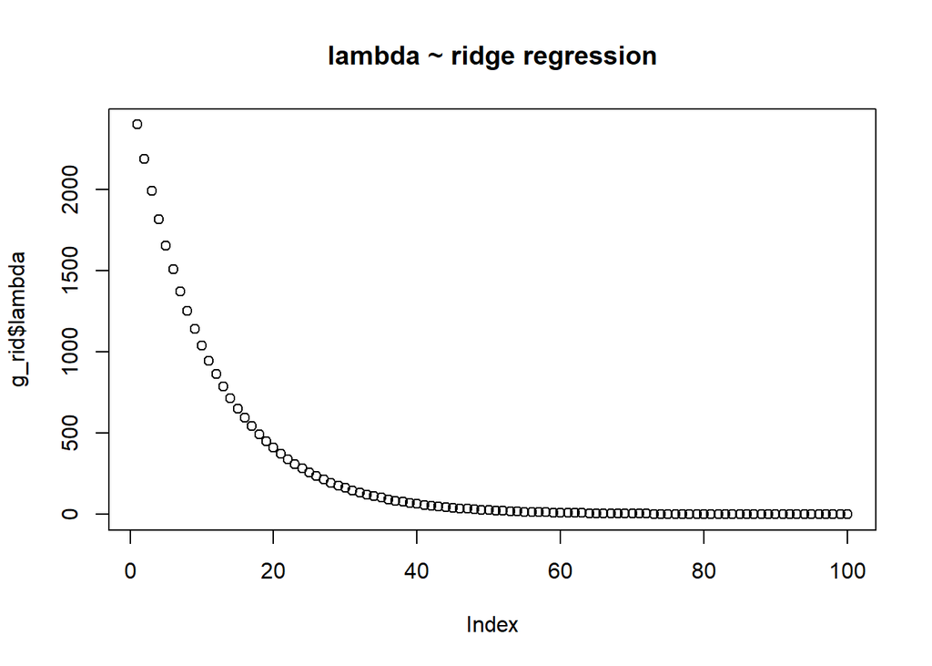

```r
plot(g_rid$lambda, main="lambda ~ ridge regression")
```

```r
#lasso regression
g_lasso <- glmnet(x, df$temp, alpha = 1)
c(g_lasso$lambda[1], g_lasso$lambda[50], g_lasso$lambda[90])
```

```
## [1] 2.4004371054 0.0251473574 0.0006085983
```

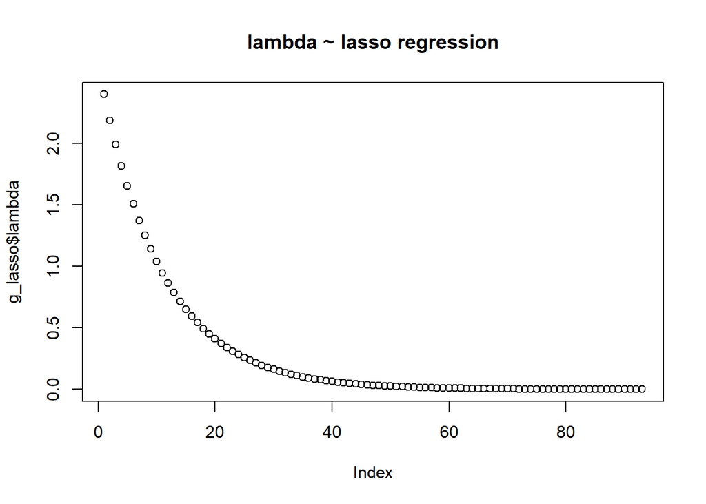

```r
plot(g_lasso$lambda, main="lambda ~ lasso regression")
```